# Alice in the Data Science World

# Clustering analysis

Targeted for students or data beginners

- Q1: What is your age (#years)?
- Q2: What is your gender?
- Q3: In which country do you currently reside?
- Q4: What is the highest level of formal education that you have attained or plan to attain within the next 2 years?
- Q6: For how many years have you been writing code and/or programming?
- Q15: For how many years have you used machine learning methods?

## Method

Since we have 6 input questions corresponding to 6 dimensions, summarizing and visualizing data can be difficult while clustering might be ineffective in high-dimensional space. To overcome these limitations, we propose first using correspondence analysis (CA), an extension of principal component analysis suited to explore relationships among qualitative variables. This technique is generally used to analyze a data set from survey to identify the associations between variable categories. Since our data contains more than two categorical variables, we choose to use multiple correspondence analysis (MCA) as it can be applied to input of multiple dimensions. However, MCA has a disadvantage that it tends not to explain all the variance while looking at associations. For the purpose of this analysis, we select the first two dimensions which altogether account for 10.5% of the total variances in the survey’s answers.

Our goal is to better understand the specific communities represented in the survey. Thus, we propose using K-means clustering, one of the simplest and most popular unsupervised technique that aims to group similar data points together and discover underlying patterns. To process the learning data and detect clusters, K-means identifies *k* number of centroids, and then allocates every data point to the nearest cluster, while keeping the centroids as small as possible. After examining different possible values of *k*, we decide to pick *k = 3*. This will help the model to avoid overfitting while ensuring its descriptive performance. Contextually, we believe 3 is a suitable number of groups of similar respondents that will allow us to dive deep into the survey datasets and tell the diverse stories of data scientists from around the world.

## Results

[output not shown]

| cluster | count |
| --- | --- |
| 1 | 5966 |
| 2 | 12039 |
| 3 | 2031 |

# Output

## Insights about jobs, salaries, companies

- Q5: Select the title most similar to your current role (or most recent title if retired)

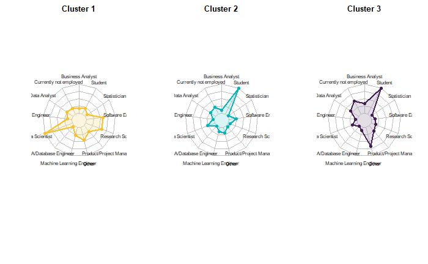

- Q20: What is the size of the company where you are employed?

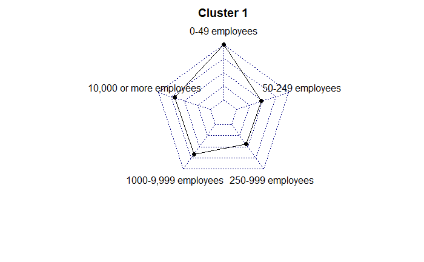

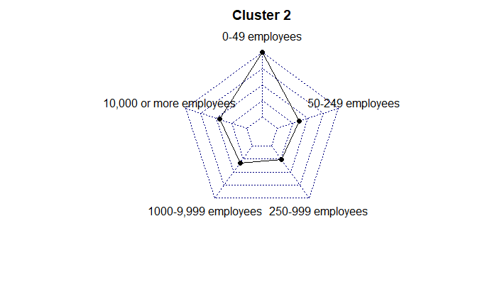

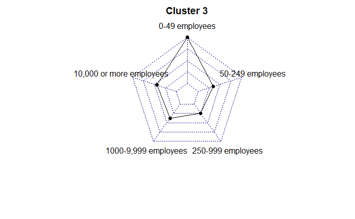

- Q21: Approximately how many individuals are responsible for data science workloads at your place at business?

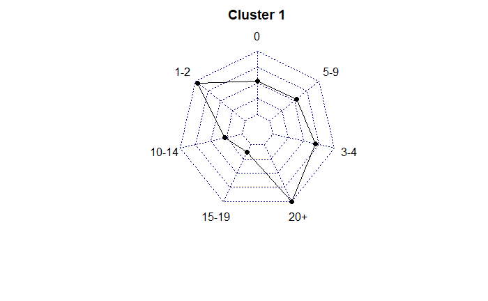

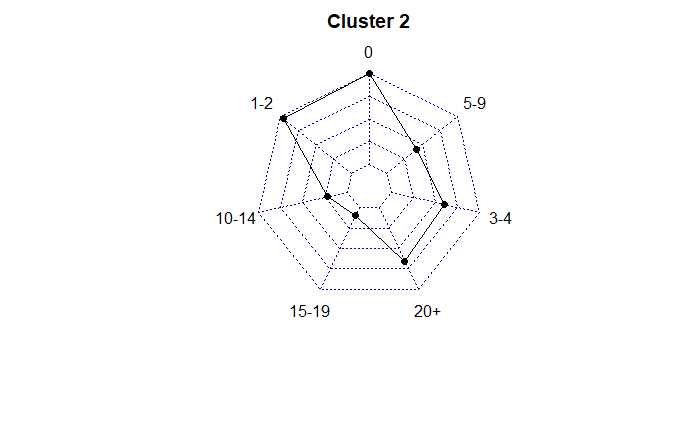

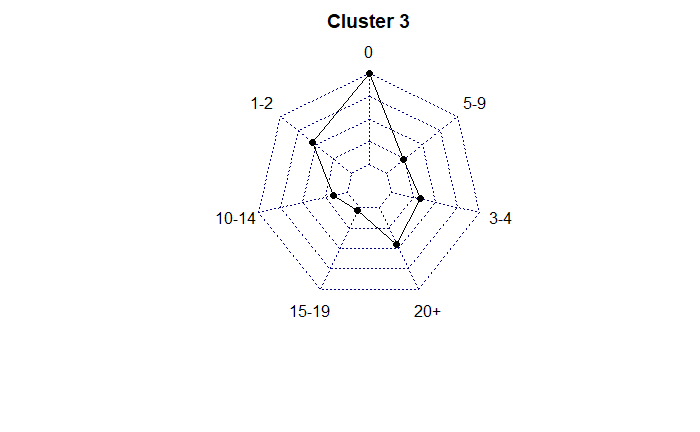

- Q22: Does your current employer incorporate machine learning methods into their business?

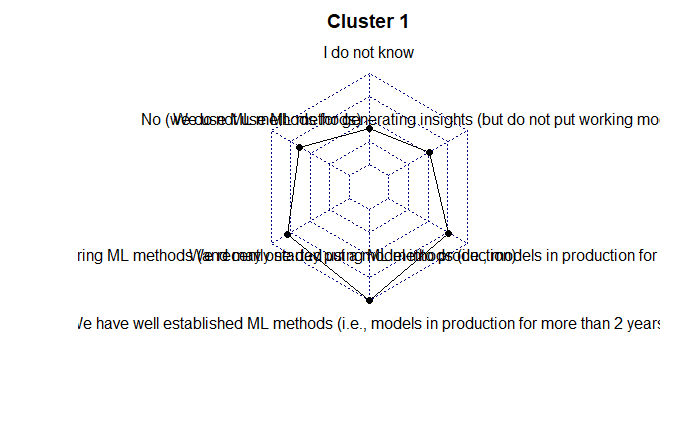

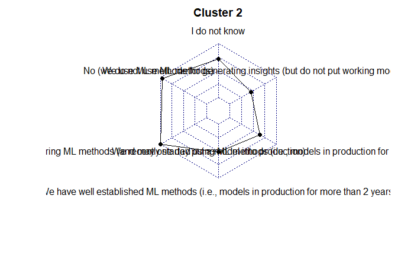

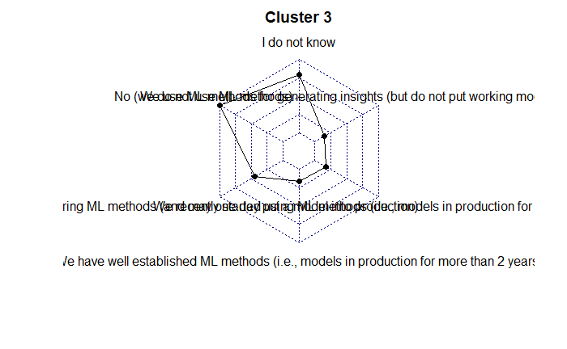

- Q23: Select any activities that make up an important part of your role at work

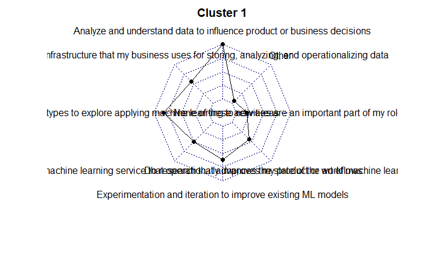

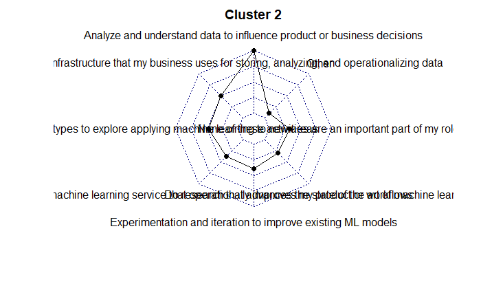

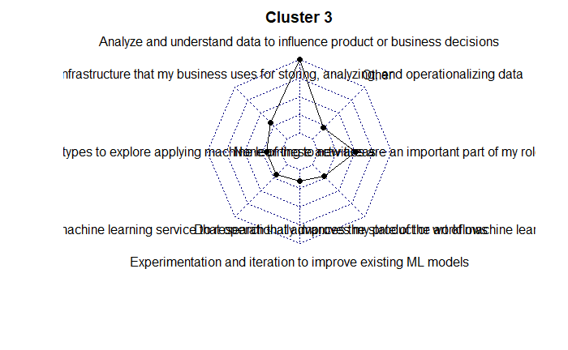

- Q24: What is your current yearly compensation (approximate $USD)?

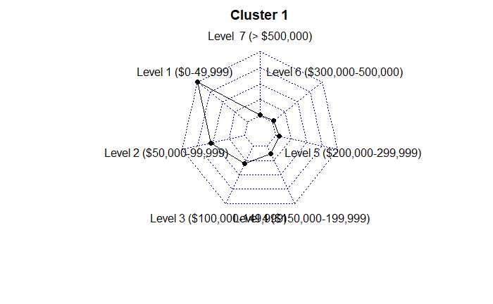

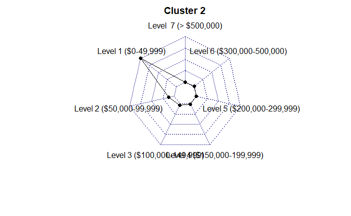

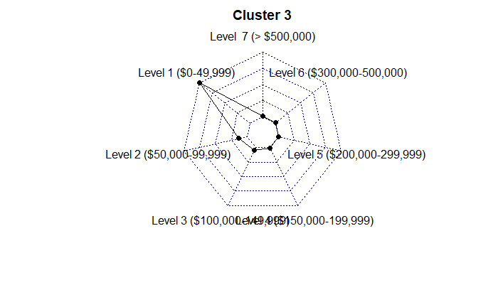

## Insights about technical skills

- Q7: What programming languages do you use on a regular basis?

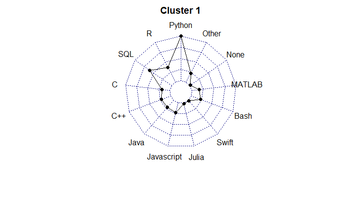

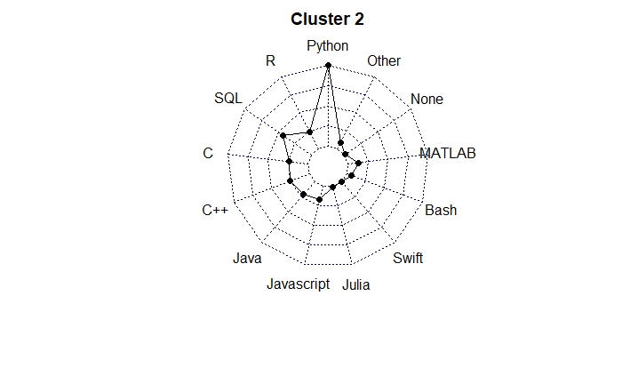

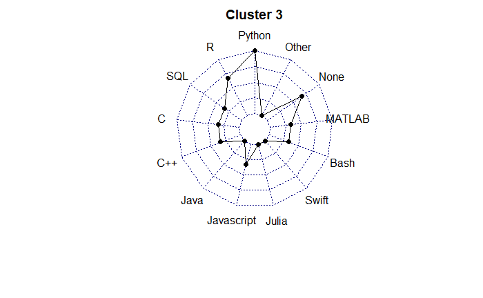

- Q8: What programming language would you recommend an aspiring data scientist to learn first?

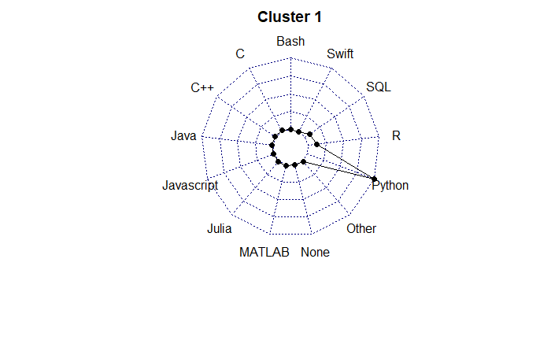

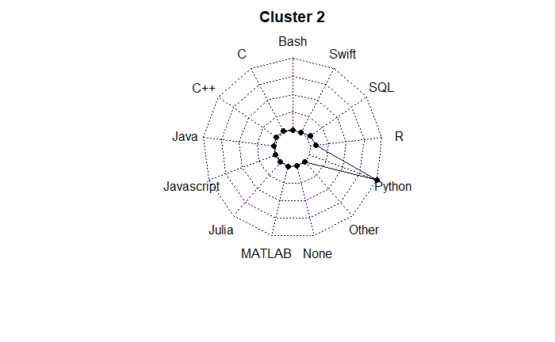

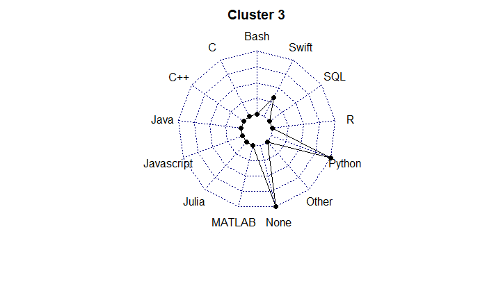

- Q9: Which of the following integrated development environments (IDE’s) do you use on a regular basis?

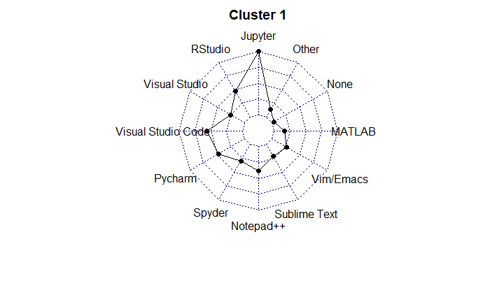

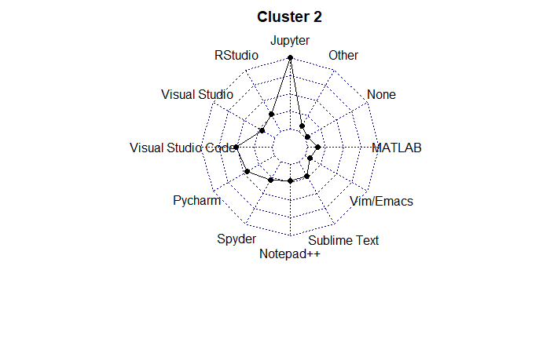

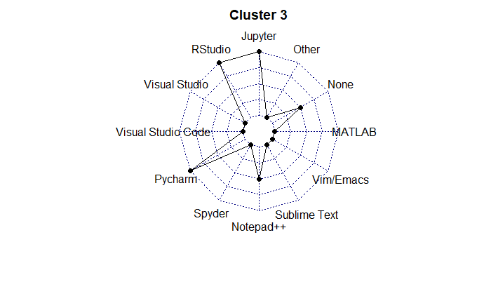

- Q14: What data visualization libraries or tools do you use on a regular basis?

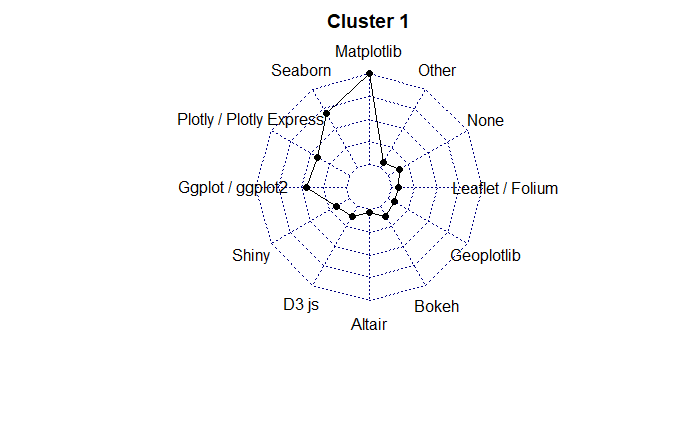

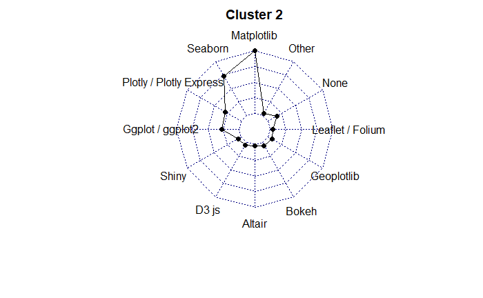

[figure not shown]

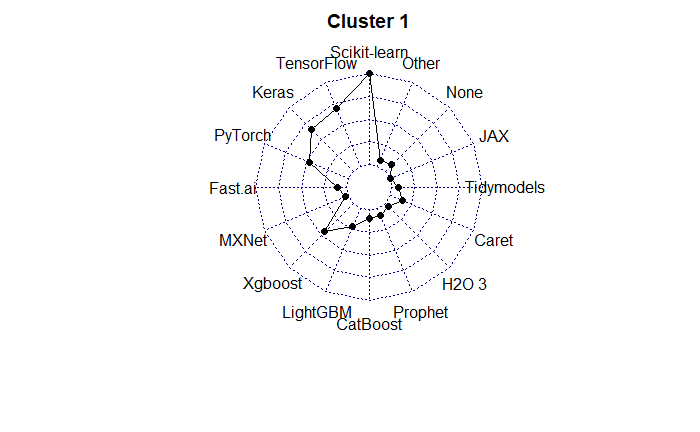

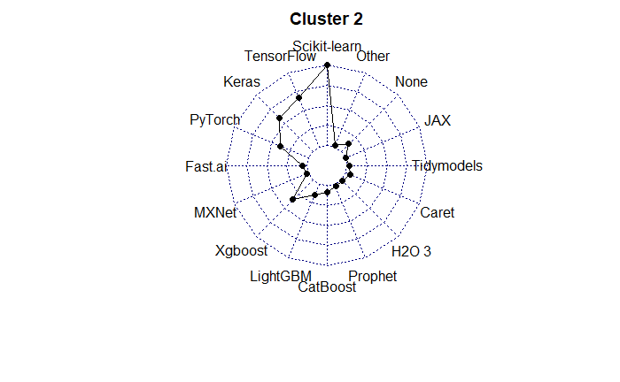

[figure not shown]

- Q29-A: Which of the following big data products (relational databases, data warehouses, data lakes, or similar) do you use on a regular basis?

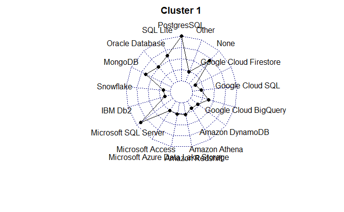